# Exploration of the Your Voice Your Choice Program

Katrina Ernst, Evans School MPA Student

INTRODUCTION: I chose to explore the data for the City of Seattle’s 2017 participatory budgeting program, called “Your Voice, Your Choice”. This was not data that I was familiar with before this project. The participatory budgeting program began by soliciting project proposals for neighborhood improvements. The program received almost 900 proposals. Those proposals were evaluated by teams, so that each City Council District voted on its top ten proposals. Voting commenced and the projects receiving the highest votes up to the maximum allowed $285,000 budget per Council District were funded. The program data was made available on the City’s Open Data platform: data.seattle.gov.

I thought this program would be interesting to explore because participatory budgeting is meant to be a way to encourage civic engagement. The program was structured to equally distribute funding, so exploring whether the variable Council District correlated to the variable Project Status, which would tell us if it was funded or not, is not interesting. However, I thought there would still be some interesting things to discover through exploratory data and text analysis (part 1). I chose to do some text analysis because the data provided includes several fields with long, unique character strings, rather than levels.

I also attempt a cluster analysis (part 2) and to map the data by Council Districts (part 3).

PART ONE: EXPLORATORY DATA AND TEXT ANALYSIS

The data was downloaded from open.seattle.gov and uploaded to my FINAL-PROJECT GitHub repo.

1. Loading the data

```r
dataLink='https://raw.githubusercontent.com/katrinae-uw/FINAL-PROJECT/master/Your_Voice_Your_Choice_Master_List_of_All_Projects_With_Scores.csv'

data=read.csv(dataLink,stringsAsFactors = F)
```

2. Verifying that it is a data frame:

```r
is.data.frame(data)
```

```
## [1] TRUE
```

3. Looking at the types for the vectors:

```r
str(data)
```

```
## 'data.frame':    874 obs. of  17 variables:
##  $ Project.Status      : chr  "On Ballot, Not Funded" "On Ballot, Not Funded" "Funded for 2018 Implementation" "On Ballot, Not Funded" ...
##  $ X1st.Review         : num  18 20 16 15 20 14 17 18 16 0 ...
##  $ X2nd.Review         : num  16 20 16 18 17 18 17 20 19 19 ...
##  $ Average.Score       : chr  "17" "20" "16" "16.5" ...
##  $ Initial.Review.Notes: chr  "" "" "" "" ...
##  $ Project..           : chr  "17-006" "17-014" "17-019" "17-031" ...
##  $ Project.Combined    : chr  "" "" "" "" ...
##  $ Project.Title       : chr  "Trail improvements @ Roxhill Park" "Improve 5-way intersection @ Dallas Ave S, 12th Ave S, and Thistle St" "Busstop improvements on Barton St" "Crossing Improvement along SW Henderson St" ...
##  $ Need.               : chr  "Trail improvements at Roxhill Park - violence and danger in park, drug use, public intoxication " "A traffic calming mechanism is much needed at a FIVE WAY intersection with no lights or stop signs at Dallas Av"| __truncated__ "The \"Delridge Bus Triangle\" located …
##  $ Idea.               : chr  "Improve lighting and trim trees around trails .. Interpretive trail improvements " "Simple all-way stop signs; adding stop signs or yield signs. Perhaps even a roundabout. Adding crosswalks (with"| __truncated__ "We have already created a \"Friends of the Delridge B…
##  $ Coordinates         : chr  "47.51775, -122.36925" "47.519390, -122.315010" "47.520934, -122.358290" "47.522840, -122.351640" ...
##  $ Location.           : chr  "Roxhill Park" "Dallas Ave S, 12th Ave S, S Thistle St" "9200 Delridge Way SW, cross streets are Barton STREET SW to the north, and 18th Ave SW to the east. " "Henderson & 13th Ave SW 98106" ...
##  $ Project.Type        : chr  "Walkways" "Crossing Improvements" "Other" "Crossing Improvements" ...
##  $ Dept.               : chr  "Parks" "SDOT" "SDOT" "SDOT" ...
##  $ Who.Benefits.       : chr  "neighbors, Westwood Village, and city of Seattle " "The neighbors who live at this intersection (some feel they are in danger of having a car come through their wi"| __truncated__ "Everyone living in along the South Delridge Corridor, with particular benefit to the …
##  $ Council.District.   : int  1 1 1 1 1 1 1 2 1 1 ...
##  $ Neighborhood        : chr  "South Delridge" "South Park" "South Delridge" "Highland Park" ...
```

4. I want to explore the variable “Average Score”. The variable “Average Score” is reading as a character, so I need to change the data type. There must be some non-number values for some observations. I will create a new variable called “Average.Numeric” and set it as numeric.

```r
data$Average.Numeric=as.numeric(as.character(data$Average.Score))
```

5. This gives the message “NAs introduced by coercion”. I will create a subset of the data called “data.sub” that will exclude the NA values from “Average.Numeric”.

```r
data.sub=data[is.na(data$Average.Numeric) == FALSE,]
```

6. I see that this take the number of observations down to 640 from 874. I will now work with the data.sub data frame.

Confirming the “Average.Numeric” is reading as a numeric vector:

```r
is.numeric(data.sub$Average.Numeric)
```

```
## [1] TRUE
```

7. Average.Numeric is reading as a numeric vector, so I will continue with my exploratory data analysis of this variable of interest.

Summary statistics for the variable Average.Numeric:

```r
summary(data.sub$Average.Numeric)
```

```
##    Min. 1st Qu.  Median    Mean 3rd Qu.    Max.
##    0.00    8.00   12.00   11.48   15.00   20.00
```

8. I am curious if the average “Average.Numeric” score for projects that were “On Ballot, Not Funded” and projects that were “Funded for 2018 Implementation” differ. I believe this may something about whether or not voters voted for projects with higher average scores.

Looking at the mean values for “Average.Numeric” by “Project.Status”.

```r
aggregate(data.sub$Average.Numeric,list(data.sub$Project.Status),mean)
```

```
##                          Group.1        x
## 1                 Already Funded 13.34286
## 2                Did Not Advance 10.54350
## 3 Funded for 2018 Implementation 15.46277
## 4                   Not Feasible 14.78409
## 5          On Ballot, Not Funded 15.80000
## 6        Referred to Maintenance  3.00000
```

9. The means don’t look very different at 15.46 and 15.8. I’ll look at their distributions by creating box plots. First load the required packages. Then create box plots looking at the “Average.Numeric” distribution by “Project.Status”:

```r
library("ggpubr")
```

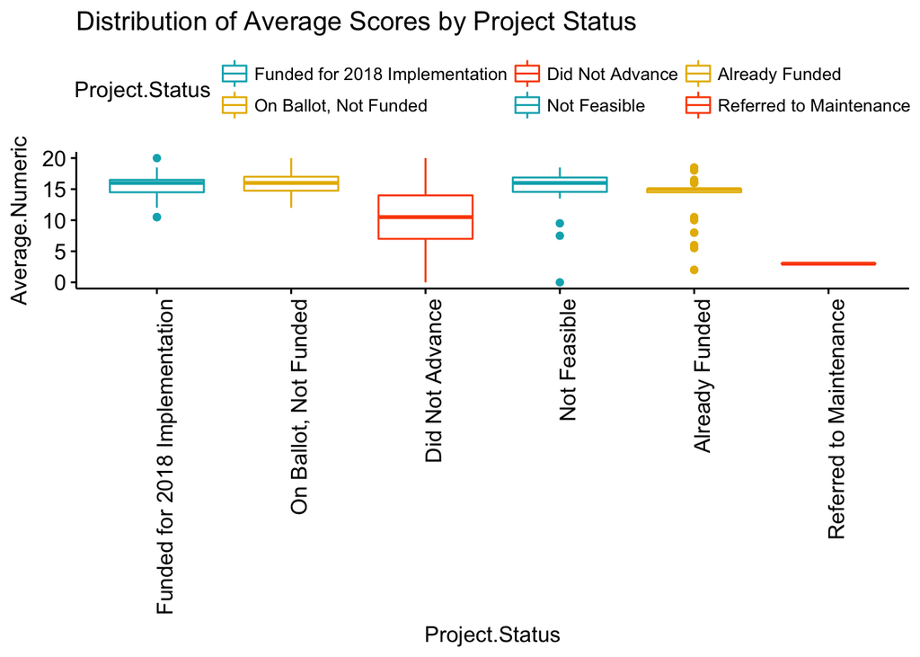

```r
library("ggplot2")
ggboxplot(data.sub, x = "Project.Status", y = "Average.Numeric",
          color = "Project.Status", palette = c("#00AFBB", "#E7B800", "#FC4E07", "#00AFBB", "#E7B800", "#FC4E07"),
          order = c("Funded for 2018 Implementation", "On Ballot, Not Funded", "Did Not Advance", "Not Feasible", "Already Funded", "Referred to Maintenance"),
          title = 'Distribution of Average Scores by Project Status',
          ylab = "Average.Numeric", xlab = "Project.Status") +
  theme(axis.text.x = element_text(angle = 90, hjust = 1))
```

10. The box plot reveals some interesting things. Namely, there was a project that scored low enough to be an outlier, but was still funded for implementation. It would be interesting to know what about that project appealed to voters.

Since voting happens by Council District, it may also be interesting to look at the data by Council District.

First, looking at the data type for the vector “Council.District.”.

```r
str(data.sub$Council.District.)
```

```
##  int [1:640] 1 1 1 1 1 1 1 2 1 1 ...
```

11. The vector is reading as an integer because the Council Districts are named 1, 2, 3, etc. However, the vector should read as a character, so I will create a new variable called “Council.District.TRUE” and verify the data type as a character:

```r
data.sub$Council.District.TRUE=as.character(data.sub$Council.District.)
is.character(data.sub$Council.District.TRUE)
```

```
## [1] TRUE
```

12. Confirmed that the variable “Council.District.TRUE” is reading as a character vector.

Looking at the means of Average.Numeric by Council.District.TRUE:

```r
aggregate(data.sub$Average.Numeric,list(data.sub$Council.District.TRUE),mean)
```

```
##   Group.1        x
## 1       1 11.82407
## 2       2 11.00000
## 3       3 12.19565
## 4       4 13.21296
## 5       5 10.53316
## 6       6 11.30000
## 7       7 10.93750
```

13. I wonder if the difference between the means by Council District is significant. I can conduct a one-way ANOVA test to see if any of the differences between the means are significant.

```r
res.aov <- aov(Average.Numeric ~ Council.District.TRUE, data = data.sub)
summary(res.aov)
```

```
##                        Df Sum Sq Mean Sq F value  Pr(>F)
## Council.District.TRUE   6    354   59.00   3.097 0.00536 **
## Residuals             633  12058   19.05
## ---
## Signif. codes:  0 '***' 0.001 '**' 0.01 '*' 0.05 '.' 0.1 ' ' 1
```

Next, I will visualize the distributions with box plots:

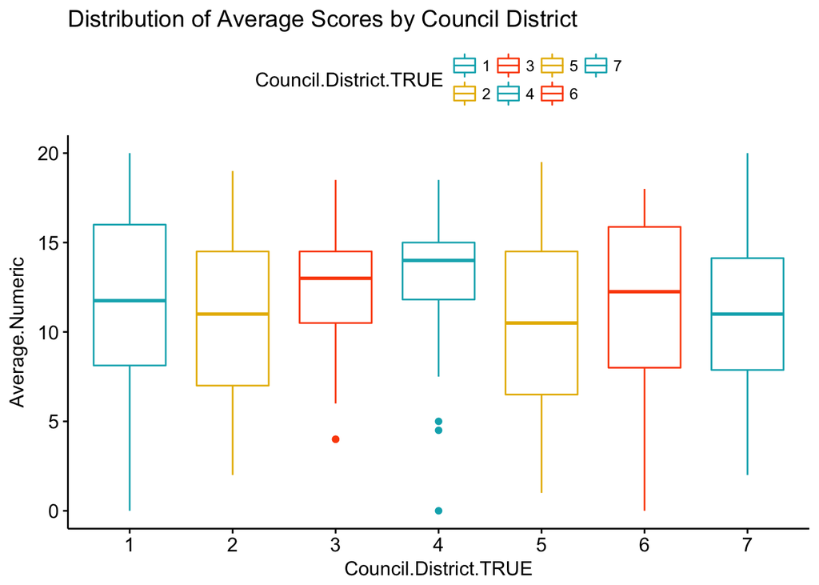

```r
ggboxplot(data.sub, x = "Council.District.TRUE", y = "Average.Numeric",
          color = "Council.District.TRUE", palette = c("#00AFBB", "#E7B800", "#FC4E07", "#00AFBB", "#E7B800", "#FC4E07", "#00AFBB"),
          order = c("1", "2", "3", "4", "5", "6", "7"),
          title = 'Distribution of Average Scores by Council District',
          ylab = "Average.Numeric", xlab = "Council.District.TRUE")
```

15. Looking at the data for “Project.Type” might also be interesting to see if there is any correlation between Council District and “Project.Type”. “Project.Type” appears to have been filled in by the data owner rather than the person proposing the project, or the proposer selected from a set categories when submitting their proposal.

First, I will look at the contigency table:

```r
table(data.sub$Project.Type,data.sub$Council.District.TRUE)
```

```
##
##                                1  2  3  4  5  6  7
##                                4  1  1  1  7  0  2
##   Accessibility Improvements   6  6  5  4  3  8  3
##   Crossing Improvements       68 32 31 26 31 38 30
##   Green Infrastructure         3  5  1  3  3  1  1
##   Lighting                     4  7  4  2  1  0  2
##   Low-cost Curbing             0  2  0  0  1  0  0
##   Other                        4  8  2  3  3  5  3
##   Park Equipment              16 14  2  4  8  0  4
##   Place-making/Beautification  3  4  0  1  0  0  2
##   School Safety                1  1  0  0  1  1  0
##   Signage                      8  5  5  2  6  3  0
##   Traffic-calming              0  1  0  0  0  0  0
##   Traffic-Calming             25 15 14  5 13 12 11
##   Walkways                    20 22  4  3 21  2  6
```

16. Just eye-balling the table, Crossing Improvements appears to be the most common for all the Council Districts.

Installing library to work with categorical-categorical data exploration and looking at another contigency table with row totals:

```r
library(gmodels)
CrossTable(data.sub$Project.Type,data.sub$Council.District.TRUE,prop.t=F, prop.r=F, prop.c=F,prop.chisq=F)
```

```
##
##
##    Cell Contents
## |-------------------------|
## |                       N |
## |-------------------------|
##
##
## Total Observations in Table:  640
##
##
##                             | data.sub$Council.District.TRUE
##       data.sub$Project.Type |         1 |         2 |         3 |         4 |         5 |         6 |         7 | Row Total |
## ----------------------------|-----------|-----------|-----------|-----------|-----------|-----------|-----------|-----------|
##                             |         4 |         1 |         1 |         1 |         7 |         0 |         2 |        16 |
## ----------------------------|-----------|-----------|-----------|-----------|-----------|-----------|-----------|-----------|
##  Accessibility Improvements |         6 |         6 |         5 |         4 |         3 |         8 |         3 |        35 |
## ----------------------------|-----------|-----------|-----------|-----------|-----------|-----------|-----------|-----------|
##       Crossing Improvements |        68 |        32 |        31 |        26 |        31 |        38 |        30 |       256 |
## ----------------------------|-----------|-----------|-----------|-----------|-----------|-----------|-----------|-----------|
##        Green Infrastructure |         3 |         5 |         1 |         3 |         3 |         1 |         1 |        17 |
## ----------------------------|-----------|-----------|-----------|-----------|-----------|-----------|-----------|-----------|
##                    Lighting |         4 |         7 |         4 |         2 |         1 |         0 |         2 |        20 |
## ----------------------------|-----------|-----------|-----------|-----------|-----------|-----------|-----------|-----------|
##            Low-cost Curbing |         0 |         2 |         0 |         0 |         1 |         0 |         0 |         3 |
## ----------------------------|-----------|-----------|-----------|-----------|-----------|-----------|-----------|-----------|
##                       Other |         4 |         8 |         2 |         3 |         3 |         5 |         3 |        28 |
## ----------------------------|-----------|-----------|-----------|-----------|-----------|-----------|-----------|-----------|
##              Park Equipment |        16 |        14 |         2 |         4 |         8 |         0 |         4 |        48 |
## ----------------------------|-----------|-----------|-----------|-----------|-----------|-----------|-----------|-----------|
## Place-making/Beautification |         3 |         4 |         0 |         1 |         0 |         0 |         2 |        10 |
## ----------------------------|-----------|-----------|-----------|-----------|-----------|-----------|-----------|-----------|
##               School Safety |         1 |         1 |         0 |         0 |         1 |         1 |         0 |         4 |
## ----------------------------|-----------|-----------|-----------|-----------|-----------|-----------|-----------|-----------|
##                     Signage |         8 |         5 |         5 |         2 |         6 |         3 |         0 |        29 |
## ----------------------------|-----------|-----------|-----------|-----------|-----------|-----------|-----------|-----------|
##             Traffic-calming |         0 |         1 |         0 |         0 |         0 |         0 |         0 |         1 |
## ----------------------------|-----------|-----------|-----------|-----------|-----------|-----------|-----------|-----------|
##             Traffic-Calming |        25 |        15 |        14 |         5 |        13 |        12 |        11 |        95 |
## ----------------------------|-----------|-----------|-----------|-----------|-----------|-----------|-----------|-----------|
##                    Walkways |        20 |        22 |         4 |         3 |        21 |         2 |         6 |        78 |
## ----------------------------|-----------|-----------|-----------|-----------|-----------|-----------|-----------|-----------|
##                Column Total |       162 |       123 |        69 |        54 |        98 |        70 |        64 |       640 |
## ----------------------------|-----------|-----------|-----------|-----------|-----------|-----------|-----------|-----------|
##
##
```

17. I want to know if Project Type is associated with Council District, so I will use a chi-squared test.

```r
CrossTable(data.sub$Project.Type,data.sub$Council.District.TRUE,prop.t=F, prop.r=F, prop.c=F,prop.chisq=F,chisq=T)
```

```
##
##
##    Cell Contents
## |-------------------------|
## |                       N |
## |-------------------------|
##
##
## Total Observations in Table:  640
##
##
##                             | data.sub$Council.District.TRUE
##       data.sub$Project.Type |         1 |         2 |         3 |         4 |         5 |         6 |         7 | Row Total |
## ----------------------------|-----------|-----------|-----------|-----------|-----------|-----------|-----------|-----------|
##                             |         4 |         1 |         1 |         1 |         7 |         0 |         2 |        16 |
## ----------------------------|-----------|-----------|-----------|-----------|-----------|-----------|-----------|-----------|
##  Accessibility Improvements |         6 |         6 |         5 |         4 |         3 |         8 |         3 |        35 |
## ----------------------------|-----------|-----------|-----------|-----------|-----------|-----------|-----------|-----------|
##       Crossing Improvements |        68 |        32 |        31 |        26 |        31 |        38 |        30 |       256 |
## ----------------------------|-----------|-----------|-----------|-----------|-----------|-----------|-----------|-----------|
##        Green Infrastructure |         3 |         5 |         1 |         3 |         3 |         1 |         1 |        17 |
## ----------------------------|-----------|-----------|-----------|-----------|-----------|-----------|-----------|-----------|
##                    Lighting |         4 |         7 |         4 |         2 |         1 |         0 |         2 |        20 |
## ----------------------------|-----------|-----------|-----------|-----------|-----------|-----------|-----------|-----------|
##            Low-cost Curbing |         0 |         2 |         0 |         0 |         1 |         0 |         0 |         3 |
## ----------------------------|-----------|-----------|-----------|-----------|-----------|-----------|-----------|-----------|
##                       Other |         4 |         8 |         2 |         3 |         3 |         5 |         3 |        28 |
## ----------------------------|-----------|-----------|-----------|-----------|-----------|-----------|-----------|-----------|
##              Park Equipment |        16 |        14 |         2 |         4 |         8 |         0 |         4 |        48 |
## ----------------------------|-----------|-----------|-----------|-----------|-----------|-----------|-----------|-----------|
## Place-making/Beautification |         3 |         4 |         0 |         1 |         0 |         0 |         2 |        10 |
## ----------------------------|-----------|-----------|-----------|-----------|-----------|-----------|-----------|-----------|
##               School Safety |         1 |         1 |         0 |         0 |         1 |         1 |         0 |         4 |
## ----------------------------|-----------|-----------|-----------|-----------|-----------|-----------|-----------|-----------|
##                     Signage |         8 |         5 |         5 |         2 |         6 |         3 |         0 |        29 |
## ----------------------------|-----------|-----------|-----------|-----------|-----------|-----------|-----------|-----------|
##             Traffic-calming |         0 |         1 |         0 |         0 |         0 |         0 |         0 |         1 |
## ----------------------------|-----------|-----------|-----------|-----------|-----------|-----------|-----------|-----------|
##             Traffic-Calming |        25 |        15 |        14 |         5 |        13 |        12 |        11 |        95 |
## ----------------------------|-----------|-----------|-----------|-----------|-----------|-----------|-----------|-----------|
##                    Walkways |        20 |        22 |         4 |         3 |        21 |         2 |         6 |        78 |
## ----------------------------|-----------|-----------|-----------|-----------|-----------|-----------|-----------|-----------|
##                Column Total |       162 |       123 |        69 |        54 |        98 |        70 |        64 |       640 |
## ----------------------------|-----------|-----------|-----------|-----------|-----------|-----------|-----------|-----------|
##
##
## Statistics for All Table Factors
##
##
## Pearson's Chi-squared test
## ------------------------------------------------------------
## Chi^2 =  109.0453     d.f. =  78     p =  0.01166714
##
##
##
```

I am also interested in the most common words used by in the project proposals to answer the question “Who Benefits?” for each project proposal. So, I will install the term frequency library and remove capitalization, numbers, common words, and punctuation.

```r
library(tm)
corpus <- Corpus(VectorSource(data.sub$Who.Benefits.)) # create corpus object
corpus <- tm_map(corpus, tolower) # convert all text to lower case
corpus <- tm_map(corpus, removePunctuation)
corpus <- tm_map(corpus, removeNumbers)
corpus <- tm_map(corpus, removeWords, stopwords('english'))
```

19. The following creates a term document matrix to see how often each of the most common words appears in each project.

```r
tdm <- TermDocumentMatrix(corpus)
count<- as.data.frame(inspect(tdm))
```

```
## <<TermDocumentMatrix (terms: 1693, documents: 640)>>
## Non-/sparse entries: 6770/1076750
## Sparsity           : 99%
## Maximal term length: 31
## Weighting          : term frequency (tf)
## Sample             :
##               Docs
## Terms          357 378 43 466 574 590 594 597 598 82
##   children       0   0  1   0   2   0   0   0   0  2
##   drivers        0   0  0   0   0   0   0   0   0  1
##   neighborhood   1   3  0   0   0   0   0   4   4  0
##   park           3   1  1   0   0   0   0   0   0  3
##   pedestrians    0   0  1   0   0   0   2   0   0  1
##   people         4   4  0   0   1   1   0   0   0  1
##   residents      0   3  0   0   0   0   0   4   4  0
##   school         0   0  1   1   3   0   0   0   0  2
##   use            1   1  0   1   0   0   0   1   1  0
##   walking        0   0  0   1   0   0   0   0   0  1
```

```r
count$word = rownames(count)
colnames(count) <- c('count','word')
count<-count[order(count$count, decreasing=TRUE), ]
```

20. This is isn’t quite what I want. I want to know the total number of project proposals that use the most frequent words for “Who Benefits”.

```r
dtm <- TermDocumentMatrix(corpus)
m <- as.matrix(dtm)
v <- sort(rowSums(m),decreasing=TRUE)
d <- data.frame(word = names(v),freq=v)
head(d, 10)
```

```
##                      word freq
## pedestrians   pedestrians  227
## residents       residents  159
## people             people  140
## park                 park  117
## neighborhood neighborhood  114
## school             school  112
## children         children  105
## drivers           drivers   92
## use                   use   82
## walking           walking   80
```

21. Now I am seeing the 10 most common words in the “Who Benefits” column. Though it could be that one project proposal uses the word pedestrians 227 times. I want to know something more like, what words appear in the field “Who Benefits” for the most counts of project proposals. I also wonder if there is any association between score and words used to describe who benefits? These are questions for future analysis.

PART TWO: CLUSTERING

22. For clustering, I want to cluster by “Project..”, so I need to first create a new variable with a substring of the character string and then set that variable as a numeric value.

```r
substr(data.sub$Project..,4,6)
```

```
##   [1] "006" "014" "019" "031" "044" "068" "085" "235" "145" "146" "147"
##  [12] "153" "163" "181" "190" "203" "676" "239" "262" "263" "266" "300"
##  [23] "319" "334" "338" "347" "348" "350" "354" "358" "677" "374" "381"
##  [34] "382" "394" "395" "411" "424" "678" "434" "439" "443" "456" "459"
##  [45] "461" "462" "485" "490" "491" "495" "499" "515" "524" "530" "531"
##  [56] "537" "570" "576" "588" "598" "599" "662" "611" "631" "632" "635"
##  [67] "636" "642" "644" "661" "679" "680" "691" "693" "696" "715" "752"
##  [78] "717" "728" "730" "737" "742" "743" "759" "761" "103" "104" "105"
##  [89] "106" "107" "108" "109" "110" "111" "112" "113" "114" "115" "116"
## [100] "117" "118" "119" "120" "121" "122" "124" "213" "230" "231" "583"
## [111] "592" "643" "668" "700" "710" "711" "749" "750" "551" "001" "002"
## [122] "003" "004" "005" "007" "013" "193" "015" "016" "020" "021" "022"
## [133] "023" "024" "025" "026" "027" "029" "030" "032" "033" "050" "034"
## [144] "035" "036" "037" "040" "042" "043" "045" "047" "048" "049" "360"
## [155] "052" "053" "054" "055" "056" "057" "059" "060" "062" "063" "064"
```

[output cut: 44 more lines]

```r
data.sub$ProjectID=substr(data.sub$Project..,4,6)
data.sub$ProjectID=as.numeric(data.sub$ProjectID)
str(data.sub$ProjectID)
```

```
##  num [1:640] 6 14 19 31 44 68 85 235 145 146 ...
```

23. I know from looking through the data frame, that the ProjectID = 400 repeats, so I will create a new data frame called data.sub2 withouth these two rows:

```r
data.sub2=data.sub[data.sub$ProjectID != 400,]
```

24. I see that the number of observations went from 640 to 638, so now I will test that the unit to be cluster appears just once in a column.

```r
length(data.sub2$ProjectID)==length(unique(data.sub2$ProjectID))
```

```
## [1] TRUE
```

25. Use the column with the names of unit of analysis as the row names.

```r
row.names(data.sub2)=data.sub2$ProjectID
```

26. Looking at the data type for columns that I will use for clustering (input columns).

```r
str(data.sub2[,c("Average.Numeric","Project.Type","Dept.")])
```

```
## 'data.frame':    638 obs. of  3 variables:
##  $ Average.Numeric: num  17 20 16 16.5 18.5 16 17 19 17.5 9.5 ...
##  $ Project.Type   : chr  "Walkways" "Crossing Improvements" "Other" "Crossing Improvements" ...
##  $ Dept.          : chr  "Parks" "SDOT" "SDOT" "SDOT" ...
```

27. Two of the variables are character strings. I need to convert these to factors. This will give us a factor variable for Project.Type with 14 levels, and a factor variable Dept. with 5 levels:

```r
factor(data.sub2$Project.Type)
```

```
##   [1] Walkways                    Crossing Improvements
##   [3] Other                       Crossing Improvements
##   [5] Crossing Improvements       Crossing Improvements
##   [7]                             Walkways
##   [9] Crossing Improvements       Crossing Improvements
##  [11] Crossing Improvements       Crossing Improvements
##  [13] Traffic-Calming             Traffic-Calming
##  [15] Lighting                    Place-making/Beautification
##  [17] Crossing Improvements       Traffic-Calming
##  [19] Accessibility Improvements  Place-making/Beautification
##  [21] School Safety               Crossing Improvements
##  [23] Accessibility Improvements  Crossing Improvements
##  [25] Accessibility Improvements  Accessibility Improvements
##  [27] Traffic-Calming             Lighting
##  [29] Traffic-Calming             Crossing Improvements
```

[output cut: 305 more lines]

```r
factor(data.sub2$Dept.)
```

```
##   [1] Parks      SDOT       SDOT       SDOT       SDOT       SDOT
##   [7] SDOT       SDOT       SDOT       SDOT       SDOT       SDOT
##  [13] SDOT       SDOT       SDOT       SDOT       SDOT       SDOT
##  [19] SDOT       SDOT       SDOT       SDOT       SDOT       SDOT
##  [25] SDOT       SDOT       SDOT       Parks      SDOT       SDOT
##  [31] SDOT       SDOT       SDOT       SDOT       SDOT       SDOT
##  [37] SDOT       SDOT       SDOT       SDOT       SDOT       SDOT
##  [43] SDOT       Parks      SDOT       SDOT       SDOT       SDOT
##  [49] SDOT       SDOT       SDOT       SDOT       SDOT       SDOT
##  [55] SDOT       SDOT       SDOT       SDOT       SDOT       Parks
##  [61] SDOT       SDOT       SDOT       SDOT       SDOT       SDOT
##  [67] SDOT       SDOT       SDOT       SDOT       SDOT       SDOT
##  [73] SDOT       SDOT       SDOT       SDOT       SDOT       SDOT
##  [79] SDOT       Parks      SDOT       SDOT       SDOT       SDOT
##  [85] SDOT       SDOT       SDOT       SDOT       SDOT       SDOT
```

[output cut: 93 more lines]

28. Saving them as factors and then looking at the data types again:

```r
data.sub2$Project.Type=as.factor(data.sub2$Project.Type)
data.sub2$Dept.=as.factor(data.sub2$Dept.)
str(data.sub2[,c("Average.Numeric","Project.Type","Dept.")])
```

```
## 'data.frame':    638 obs. of  3 variables:
##  $ Average.Numeric: num  17 20 16 16.5 18.5 16 17 19 17.5 9.5 ...
##  $ Project.Type   : Factor w/ 14 levels "","Accessibility Improvements",..: 14 3 7 3 3 3 1 14 3 3 ...
##  $ Dept.          : Factor w/ 5 levels "Parks","Parks/SDOT",..: 1 3 3 3 3 3 3 3 3 3 ...
```

29. I have a mix of data types, so I produce a similarity matrix with “gower”.

```r
library(cluster)
dataSimi=daisy(data.sub2[,c("Average.Numeric","Project.Type","Dept.")],metric = "gower",
               stand=TRUE)
```

30. Applying the clustering technique:

```r
dataClus=hclust(dataSimi,method = 'average')
```

31. Comparing visually:

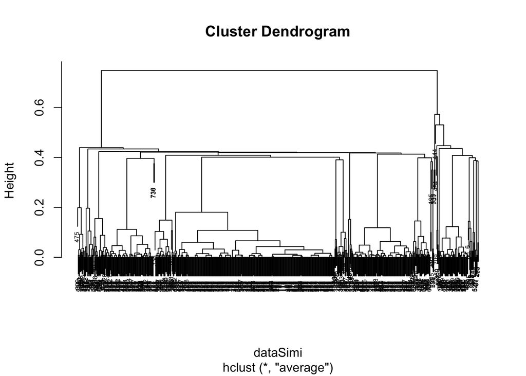

```r
plot(dataClus,cex=0.5)
```

32. Trying with a different numbers of clusters highlighted with color borders:

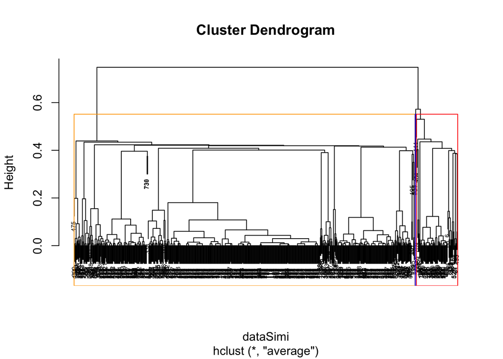

```r
plot(dataClus,cex=0.5)
rect.hclust(dataClus, k = 3,border = c('orange','blue','red','green'))
```

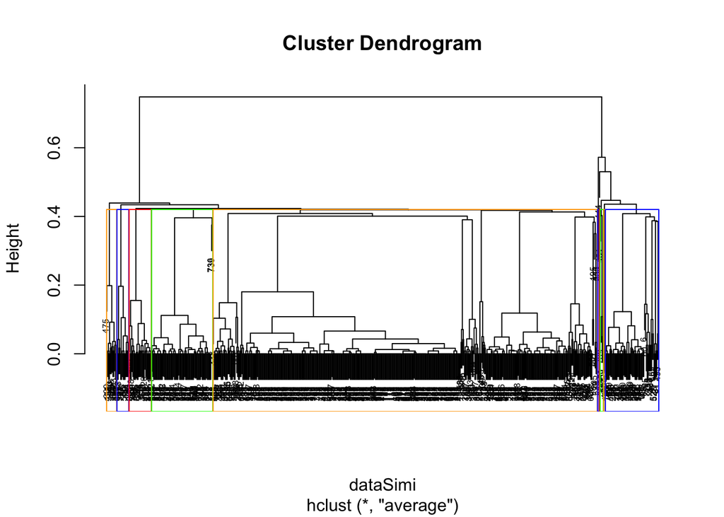

```r
plot(dataClus,cex=0.5)
rect.hclust(dataClus, k = 10,border = c('orange','blue','red','green'))
```

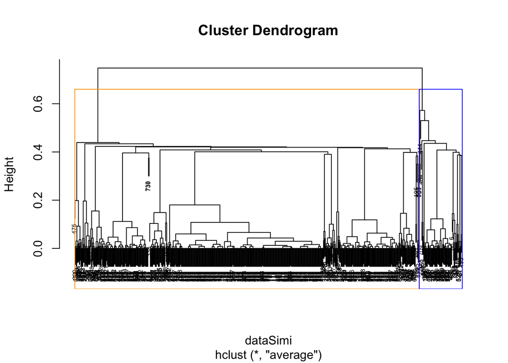

```r
plot(dataClus,cex=0.5)
rect.hclust(dataClus, k = 2,border = c('orange','blue','red','green'))
```

33. Plotting suggests two clusters, so I’ll compare numerically with 2:

```r
datasil2=silhouette(cutree(dataClus, k = 2), dataSimi)
clust2solution=data.frame(matrix(datasil2,ncol = 3,dimnames = dimnames(datasil2)))
row.names(clust2solution)=data.sub2$ProjectID
(bad2=clust2solution[clust2solution$sil_width<0,])
```

```
## [1] cluster   neighbor  sil_width
## <0 rows> (or 0-length row.names)
```

34. That didn’t find any rows, so maybe I need to increase the number of clusters:

```r
datasil10=silhouette(cutree(dataClus, k = 10), dataSimi)
clust10solution=data.frame(matrix(datasil10,ncol = 3,dimnames = dimnames(datasil10)))
row.names(clust10solution)=data.sub2$ProjectID
(bad10=clust10solution[clust10solution$sil_width<0,])
```

```
##     cluster neighbor    sil_width
## 6         1        6 -0.124882408
## 668       2        7 -0.072453796
## 21        2        7 -0.077368599
## 60        1       10 -0.165897858
## 63        1       10 -0.158131028
## 75        2        7 -0.008382150
## 101       2        7 -0.069286129
## 102       2        7 -0.113329943
## 123       2        7 -0.034768903
## 136       2        7 -0.004200536
## 139       2        7 -0.120331138
## 155       2        7 -0.140274621
## 192       2        7 -0.112494649
## 195       2        7 -0.068536662
```

[output cut: 22 more lines]

35. That produced something. I’ll also try 9 clusters:

```r
datasil9=silhouette(cutree(dataClus, k = 9), dataSimi)
clust9solution=data.frame(matrix(datasil9,ncol = 3,dimnames = dimnames(datasil9)))
row.names(clust9solution)=data.sub2$ProjectID
(bad9=clust9solution[clust9solution$sil_width<0,])
```

```
##     cluster neighbor     sil_width
## 6         1        5 -0.1248824083
## 668       2        6 -0.0790979767
## 21        2        6 -0.0832766140
## 35        2        6 -0.0049017589
## 60        1        9 -0.1658978583
## 63        1        9 -0.1581310276
## 75        2        6 -0.0151249541
## 101       2        6 -0.0705244123
## 102       2        6 -0.1191752071
## 123       2        6 -0.0410067087
## 136       2        6 -0.0278913384
## 139       2        6 -0.1218432293
## 155       2        6 -0.1420993667
## 192       2        6 -0.1184164562
```

[output cut: 34 more lines]

36. Identify what units of analysis are difficult to cluster.

```r
intersect(row.names(bad9),row.names(bad10))
```

```
##  [1] "6"   "668" "21"  "60"  "63"  "75"  "101" "102" "123" "136" "139"
## [12] "155" "192" "195" "205" "234" "251" "272" "274" "275" "292" "405"
## [23] "436" "532" "522" "539" "602" "604" "606" "640" "667" "684" "685"
## [34] "689" "708" "745"
```

All 36 rows from the cluster10 are difficult to cluster, so I think this indicates that the data is difficult to cluster. I will continue to use the data frame data.sub for mapping the data.

PART THREE: MAPPING

37. I downloaded a shapefile from: https://data.seattle.gov/dataset/Council-Districts/wud8-na47. This dataset contains map information for Seattle’s Council Districts. I uploaded the zip file to GitHub.

Unzipping and reading the zip file with required packages installed first:

```r
compressedMap="https://github.com/katrinae-uw/FINAL-PROJECT/raw/master/Council_Districts.zip"

library(utils)
temp=tempfile()
download.file(compressedMap, temp)
unzip(temp)
```

38. Looking to see what shapefiles there are:

```r
(maps=list.files(pattern = 'shp'))
```

```
## [1] "Council_Districts.shp"
```

39. I see the name of the shapefile. I will name my map “CDMap” for “Council District Map”. With needed packages loaded, selecting the maps that I need for “CDMap”:

```r
library(rgdal)
CDMap <- rgdal::readOGR('Council_Districts.shp',stringsAsFactors=F)
```

40. Looking at what I have in the map:

```r
names(CDMap)
```

```
## [1] "OBJECTID"   "C_DISTRICT" "DISPLAY_NA" "Shape_Leng" "Shape_Area"
```

41. Checking data type of “C_District”:

```r
str(CDMap$C_DISTRICT)
```

```
##  chr [1:7] "4" "3" "1" "2" "6" "5" "7"
```

42. In the map file, Council District is read as a character. This matches “Council.District.TRUE” that I created in the data.sub data frame. Good!

Now, I need to create a new data frame that aggregates the count of project proposals by Council_District_TRUE.

Creating a new column that is full of number 1 (this will be the numeric column when creating the new data frame for the map) and testing that it is numeric:

```r
data.sub["count"] <- 1

is.numeric(data.sub$count)
```

```
## [1] TRUE
```

43. I now have a column with “1” for each row so I can aggregate by Council_District_TRUE. I will name the new data frame “data_by_CD”.

```r
numericColumns=c("count")
aggregateBY='Council.District.TRUE'

data_by_CD=aggregate(data.sub[,numericColumns], by=list(data.sub[,aggregateBY]),sum)
names(data_by_CD)=c('Council.District.TRUE', 'count')
data_by_CD
```

```
##   Council.District.TRUE count
## 1                     1   162
## 2                     2   123
## 3                     3    69
## 4                     4    54
## 5                     5    98
## 6                     6    70
## 7                     7    64
```

44. Now I will merge the map file with data_by_CD and name the new map “CD_projects_map”.

```r
CD_projects_map=merge(CDMap,data_by_CD, by.x='C_DISTRICT', by.y='Council.District.TRUE',all.x=F)
```

45. Trying mapping both:

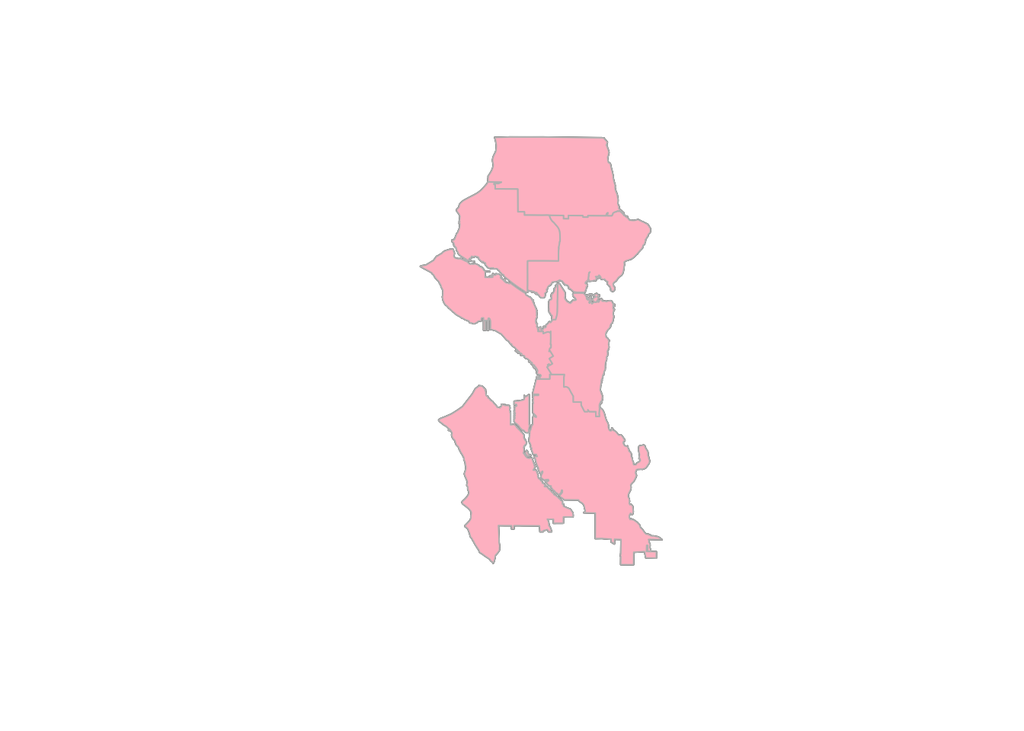

```r
plot(CDMap,col='black')
plot(CD_projects_map,col='pink',border='grey',add=T)
```

46. I get a map, so it is working. Now I want to map the variable “count”.

Install and load the necessary packages to manage color and divisions:

```r
library(RColorBrewer)
library(classInt)
```

47. Define the input:

```r
varToPLot=CD_projects_map$count
```

48. Get colors and intervals:

```r
numberOfClasses = 5
colorForScale='YlGnBu'
colors = brewer.pal(numberOfClasses, colorForScale)
intervals <- classIntervals(varToPLot, numberOfClasses,
                            style = "quantile",
                            dataPrecision=2)
colorPallette <- findColours(intervals, colors)
```

49. Map:

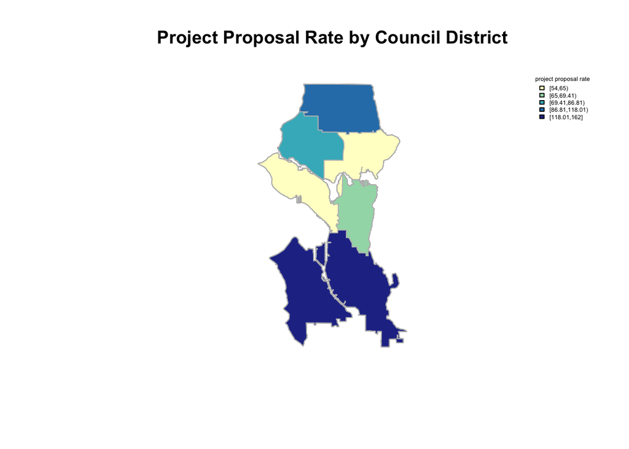

```r
legendText="project proposal rate"
shrinkLegend=0.4
title="Project Proposal Rate by Council District"

plot(CDMap,col='red',main=title)
plot(CD_projects_map, col = colorPallette,border='grey',add=T)

legend('topright', legend = names(attr(colorPallette, "table")),
       fill = attr(colorPallette, "palette"), cex = shrinkLegend,
       bty = "n",
       title=legendText)
```

The map shows us that the southern Seattle Council Districts had greater number of proposals, with the Council Districts in the middle of the City having the fewest. Proposals were concentrated in the sourthern and northern Council Districts. This is interesting to note. It may mean that there is more need in those Council Districts for these types of projects, or that the residents on more civically engaged and therefore more likely to put in proposals, or outreach efforts might have been concentrated in those locations.